# Weekly report

Fangshu Ye

5/28/2020

### 0. What I did this week

- Modify the first part: **Data Checking** (remove the outlier of age; drop the data from people who are not consistent with MostAttach)
- Almost finished the third part: **Cat owners versus dogs owners**

### 1. Remaining questions

Q1: Select the variables that we’re gone to analyze.

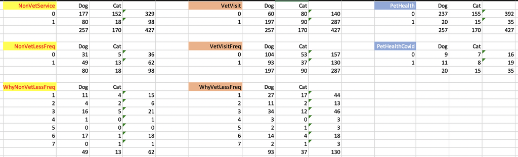

Q2: ‘Twice’ or ‘Once and Twice’

Here we take **Interact** for example:

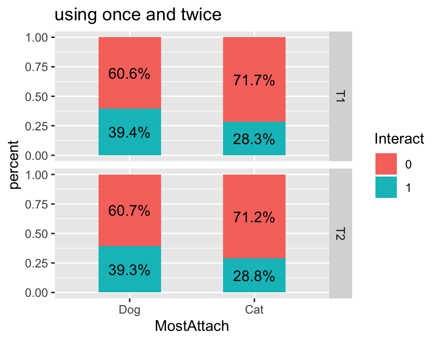

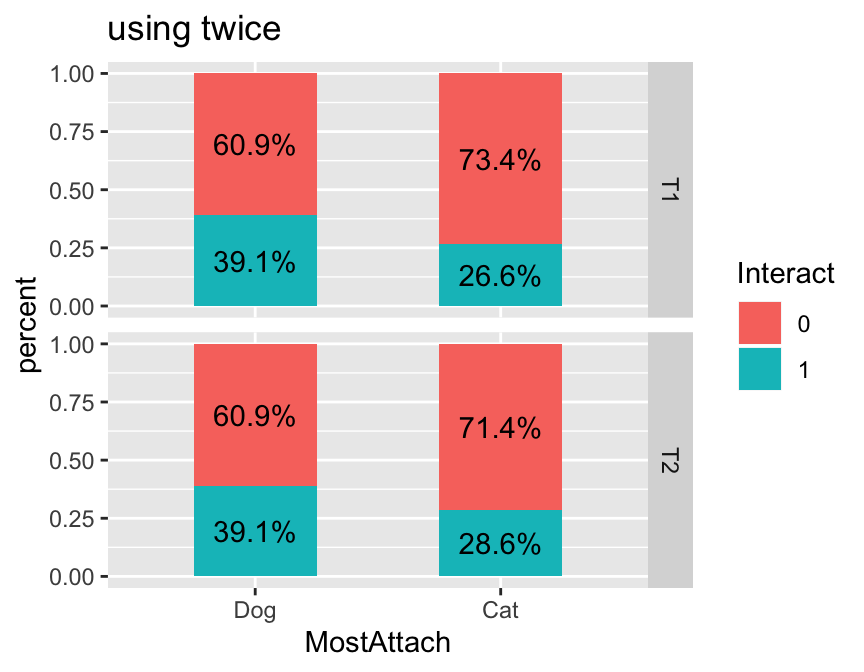

Coef of ‘MostAttachCat’ in logistic regression ‘Interact ~ MostAttach’, using WAVE1

|  | Estimate | Std. Error | z value | Pr(>\|z\|) |
| --- | --- | --- | --- | --- |
| include both once and twice | -0.5024094 | 0.2007585 | -2.502556 | 0.0123300 |
| only twice | -0.5694352 | 0.2297348 | -2.478663 | 0.0131876 |

Coef of ‘MostAttachCat’ in logistic regression ‘Interact ~ MostAttach’, using WAVE2

|  | Estimate | Std. Error | z value | Pr(>\|z\|) |
| --- | --- | --- | --- | --- |
| include both once and twice | -0.4675496 | 0.2234900 | -2.092039 | 0.0364351 |
| only twice | -0.4719102 | 0.2266197 | -2.082388 | 0.0373070 |

Coef of ‘MostAttachCat’ and ‘timeT2’ in logistic regression ‘Interact ~ MostAttach + time + (1|workerId)’, using WAVE1+WAVE2

|  | Estimate | Std. Error | z value | Pr(>\|z\|) |
| --- | --- | --- | --- | --- |
| **include both once and twice** |  |  |  |  |
| MostAttachCat | -1.0610640 | 0.3858877 | -2.7496708 | 0.0059655 |
| timeT2 | 0.0499987 | 0.2135023 | 0.2341836 | 0.8148425 |
| **only twice** |  |  |  |  |
| MostAttachCat | -1.2266223 | 0.4518822 | -2.7144734 | 0.0066381 |
| timeT2 | 0.0756200 | 0.2246312 | 0.3366405 | 0.7363879 |

use once+twice in the following analysis

### 2. Modeling reuslt

Data size:

```r
table(alldata$time)
```

```
##
##  T1  T2
## 480 380
```

#### 2.1 Common questions for wave1 and wave2

##### 2.1.1 **Compliance** (Yes:1;No:0) : Does your pet/companion animal(s) influence your compliance with quarantine recommendations and requirements in your region?

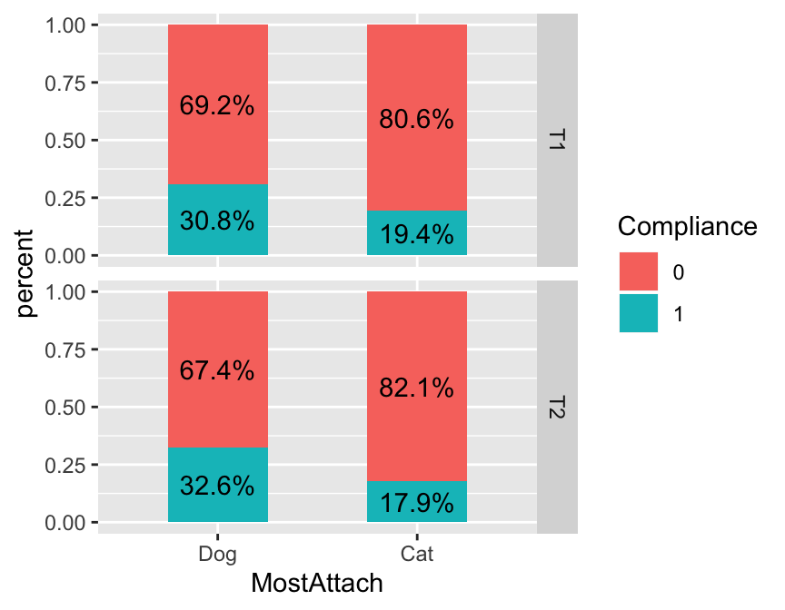

| Logistic | Estimate | Std. Error | pvalue |
| --- | --- | --- | --- |
| **T1: Compliance ~ MostAttach** |  |  |  |
| MostAttachCat | -0.6163537 | 0.2230616 | 0.0057 |
| **T2: Compliance ~ MostAttach** |  |  |  |
| MostAttachCat | -0.7930054 | 0.2526815 | 0.0017 |
| **T1+T2: Compliance ~ MostAttach + time + (1\|workerId)** |  |  |  |
| MostAttachCat | -0.9947554 | 0.7168859 | 0.1653 |
| timeT2 | 1.2484770 | 0.4250846 | 0.0033 |
| **T1+T2: Compliance ~ MostAttach + time + MostAttach*time + (1\|workerId)** |  |  |  |
| MostAttachCat | -0.6307238 | 0.9366496 | 0.5007 |
| timeT2 | 1.3947018 | 0.5005106 | 0.0053 |
| MostAttachCat:timeT2 | -0.5258575 | 0.8959670 | 0.5573 |

##### 2.1.2 **Interact** (Yes:1;No:0) : Has COVID-19 affected your normal activities and interactions with your pet/companion animal(s)?

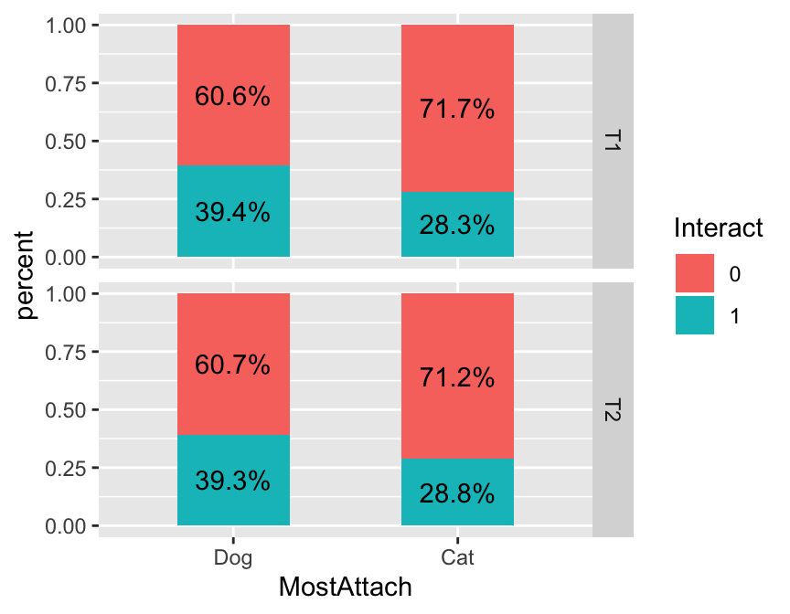

| Logistic | Estimate | Std. Error | pvalue |
| --- | --- | --- | --- |
| **T1: Interact ~ MostAttach** |  |  |  |
| MostAttachCat | -0.5024094 | 0.2007585 | 0.0123 |
| **T2: Interact ~ MostAttach** |  |  |  |
| MostAttachCat | -0.4675496 | 0.2234900 | 0.0364 |
| **T1+T2: Interact ~ MostAttach + time + (1\|workerId)** |  |  |  |
| MostAttachCat | -1.0610640 | 0.3858877 | 0.006 |
| timeT2 | 0.0499987 | 0.2135023 | 0.8148 |
| **T1+T2: Interact ~ MostAttach + time + MostAttach*time + (1\|workerId)** |  |  |  |
| MostAttachCat | -1.1126602 | 0.4299982 | 0.0097 |
| timeT2 | 0.0026439 | 0.2740997 | 0.9923 |
| MostAttachCat:timeT2 | 0.1203531 | 0.4368689 | 0.7829 |

##### 2.1.3 **Plans** (Yes:1;No:0): Since the COVID-19 outbreak, have you made plans for caring for your pet/companion animal(s) should you become sick and unable to care for them?

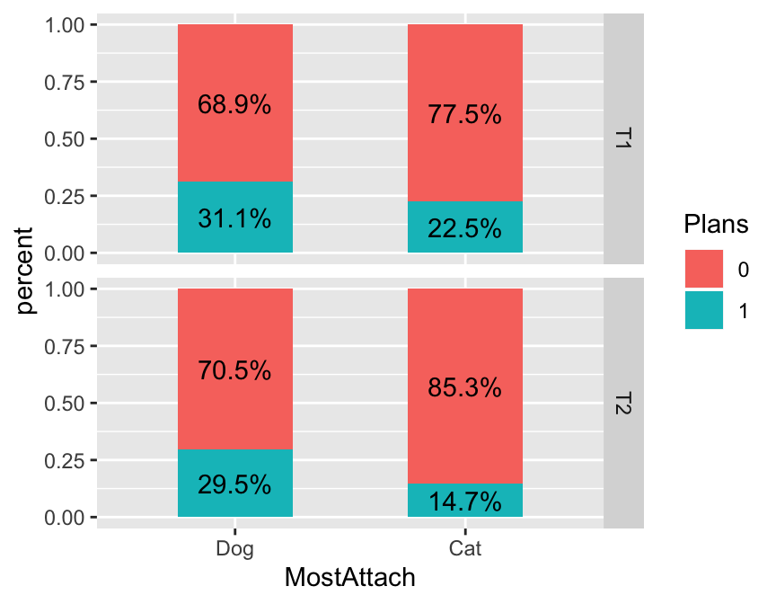

| Logistic | Estimate | Std. Error | pvalue |
| --- | --- | --- | --- |
| **T1: Plans ~ MostAttach** |  |  |  |
| MostAttachCat | -0.4425170 | 0.2148226 | 0.0394 |
| **T2: Plans ~ MostAttach** |  |  |  |
| MostAttachCat | -0.8819146 | 0.2692168 | 0.0011 |
| **T1+T2: Plans ~ MostAttach + time + (1\|workerId)** |  |  |  |
| MostAttachCat | -0.7749292 | 0.6541833 | 0.2362 |
| timeT2 | -0.3495586 | 0.3629035 | 0.3354 |
| **T1+T2: Plans ~ MostAttach + time + MostAttach*time + (1\|workerId)** |  |  |  |
| MostAttachCat | -0.3561467 | 0.6989369 | 0.6104 |
| timeT2 | 0.0750194 | 0.4425664 | 0.8654 |
| MostAttachCat:timeT2 | -1.2988318 | 0.8054147 | 0.1068 |

##### 2.1.4 **Concern**(1-5: Not at all concerned to Extremely concerned): Overall, how concerned are you about your ability to care for your pets/companion animal(s)?

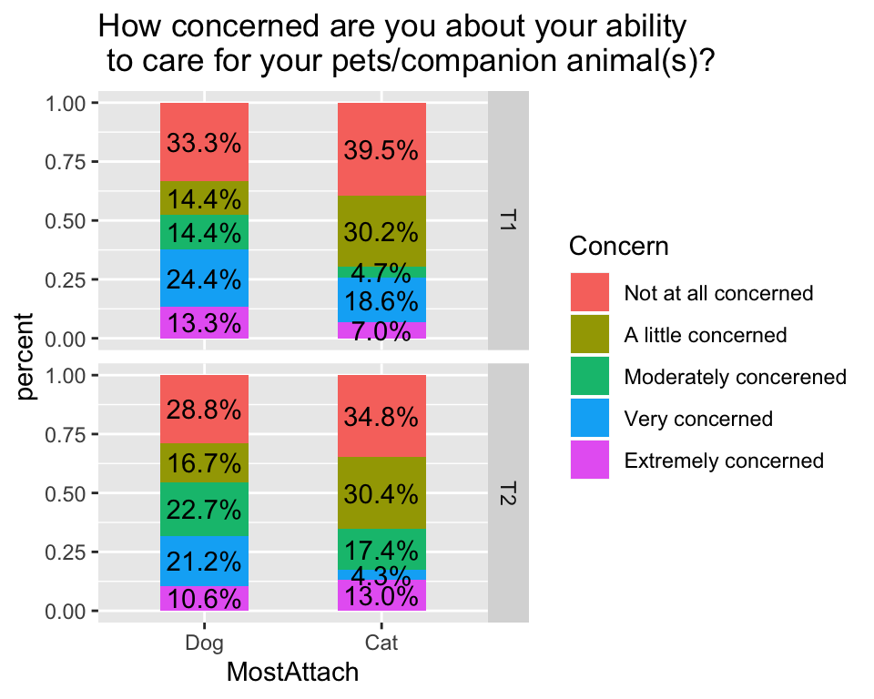

Ordinal Logistic Regression: Concern ~ MostAttach + time + MostAttach*time + (1|workerId)

|  | Estimate | Std. Error | z value | Pr(>\|z\|) |
| --- | --- | --- | --- | --- |
| MostAttachCat | -0.9382738 | 0.4640120 | -2.0220893 | 0.0431671 |
| timeT2 | -0.0489942 | 0.2295504 | -0.2134353 | 0.8309874 |
| MostAttachCat:timeT2 | 0.2404212 | 0.3632472 | 0.6618667 | 0.5080567 |

##### 2.1.5 CCAS1-13

Ordinal Logistic Regression: y ~ MostAttach + time + MostAttach*time + (1|workerId)

| Ordinal | Estimate | Std. Error | pvalue |
| --- | --- | --- | --- |
| **CCAS1: My pet/animal provides me with companionship** |  |  |  |
| MostAttachCat | -0.2698497 | 0.4030631 | 0.5032 |
| timeT2 | 0.4721359 | 0.2362008 | 0.0456 |
| MostAttachCat:timeT2 | 0.0536130 | 0.3628666 | 0.8825 |
| **CCAS2: Having a pet/animal gives me something to care for** |  |  |  |
| MostAttachCat | 0.3145534 | 0.0001529 | 0 |
| timeT2 | 0.1491087 | 0.0001529 | 0 |
| MostAttachCat:timeT2 | 0.1020812 | 0.0001529 | 0 |
| **CCAS3: My pet/animal provides me with pleasurable activity** |  |  |  |
| MostAttachCat | -0.3804286 | 0.3445651 | 0.2696 |
| timeT2 | -0.0547894 | 0.2111836 | 0.7953 |
| MostAttachCat:timeT2 | 0.2077084 | 0.3287708 | 0.5275 |
| **CCAS4: My pet/animal is a source of constancy in my life** |  |  |  |
| MostAttachCat | 0.1687528 | 0.3400460 | 0.6197 |
| timeT2 | 0.0281922 | 0.2111920 | 0.8938 |
| MostAttachCat:timeT2 | -0.0674638 | 0.3248187 | 0.8355 |
| **CCAS5: My pet/animal makes me feel needed** |  |  |  |
| MostAttachCat | -0.2698679 | 0.0020003 | 0 |
| timeT2 | 0.0921971 | 0.0020642 | 0 |
| MostAttachCat:timeT2 | 0.2744417 | 0.0020643 | 0 |
| **CCAS6: My pet/animal makes me feel safe** |  |  |  |
| MostAttachCat | -1.7574944 | 0.3415401 | 0 |
| timeT2 | 0.0643733 | 0.1932925 | 0.7391 |
| MostAttachCat:timeT2 | 0.0803449 | 0.2961868 | 0.7862 |
| **CCAS7: My pet/animal makes me play and laugh** |  |  |  |
| MostAttachCat | -0.1439663 | 0.3188544 | 0.6516 |
| timeT2 | -0.0352459 | 0.2067455 | 0.8646 |
| MostAttachCat:timeT2 | 0.2322009 | 0.3228738 | 0.472 |
| **CCAS8: Having a pet/animal gives me something to love** |  |  |  |
| MostAttachCat | 0.3343721 | 0.3732869 | 0.3704 |
| timeT2 | 0.1298732 | 0.2191391 | 0.5534 |
| MostAttachCat:timeT2 | -0.0778953 | 0.3412342 | 0.8194 |
| **CCAS9: I get more exercise because of my pet/animal** |  |  |  |
| MostAttachCat | -3.8823772 | 0.3838137 | 0 |
| timeT2 | 0.1598228 | 0.1915768 | 0.4041 |
| MostAttachCat:timeT2 | -0.2402878 | 0.2934478 | 0.4129 |
| **CCAS10: I get comfort from touching my pet/animal** |  |  |  |
| MostAttachCat | 0.5877015 | 0.4045642 | 0.1463 |
| timeT2 | 0.3104265 | 0.2259477 | 0.1695 |
| MostAttachCat:timeT2 | -0.2361642 | 0.3507624 | 0.5008 |
| **CCAS11: I enjoy watching my pet/animal** |  |  |  |
| MostAttachCat | 0.6656347 | 0.4432257 | 0.1331 |
| timeT2 | 0.1695589 | 0.2347960 | 0.4702 |
| MostAttachCat:timeT2 | 0.4677229 | 0.3788927 | 0.217 |
| **CCAS12: My pet/animal makes me feel loved** |  |  |  |
| MostAttachCat | -0.5497169 | 0.3604777 | 0.1273 |
| timeT2 | 0.3202461 | 0.2167424 | 0.1395 |
| MostAttachCat:timeT2 | -0.3055313 | 0.3296589 | 0.354 |
| **CCAS13: My pet/animal makes me feel trusted** |  |  |  |
| MostAttachCat | 0.0022916 | 0.3185943 | 0.9943 |
| timeT2 | 0.1152466 | 0.2022367 | 0.5688 |
| MostAttachCat:timeT2 | -0.0261144 | 0.3151679 | 0.934 |

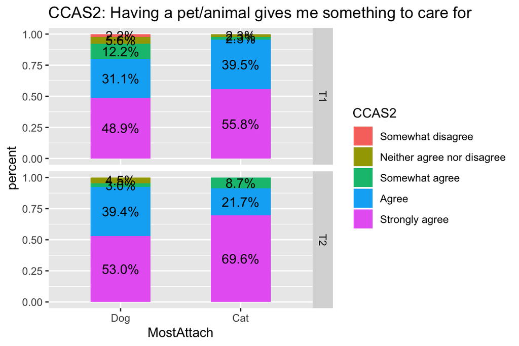

#### 2.2 Unique questions for wave2

##### 2.2.1 (Yes:1;No:0) : In the past 12 months have you used an animal care service that does NOT normally require a veterinarian?

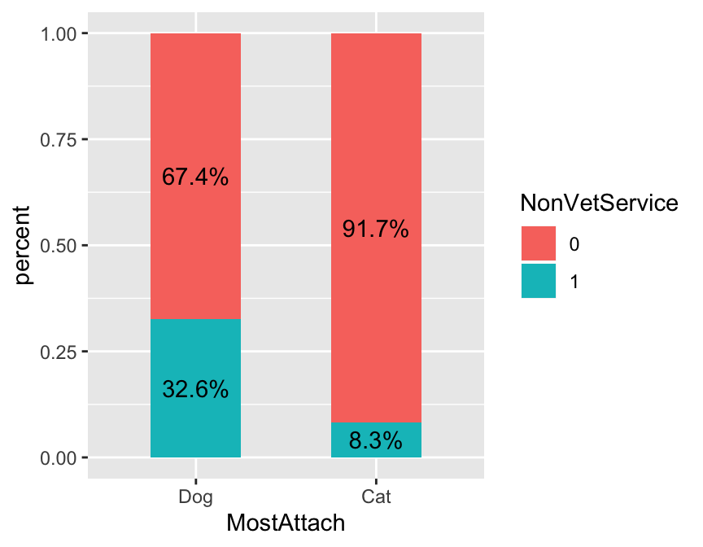

```
##                 Estimate Std. Error   z value     Pr(>|z|)
## (Intercept)   -0.7268204  0.1425523 -5.098624 3.421311e-07
## MostAttachCat -1.6710749  0.3228579 -5.175884 2.268343e-07
```

##### 2.2.2 (Yes:1;No:0) : Thinking about the time since the COVID-19 outbreak began, have you used any of these non-veterinary services less frequently than before the outbreak began?

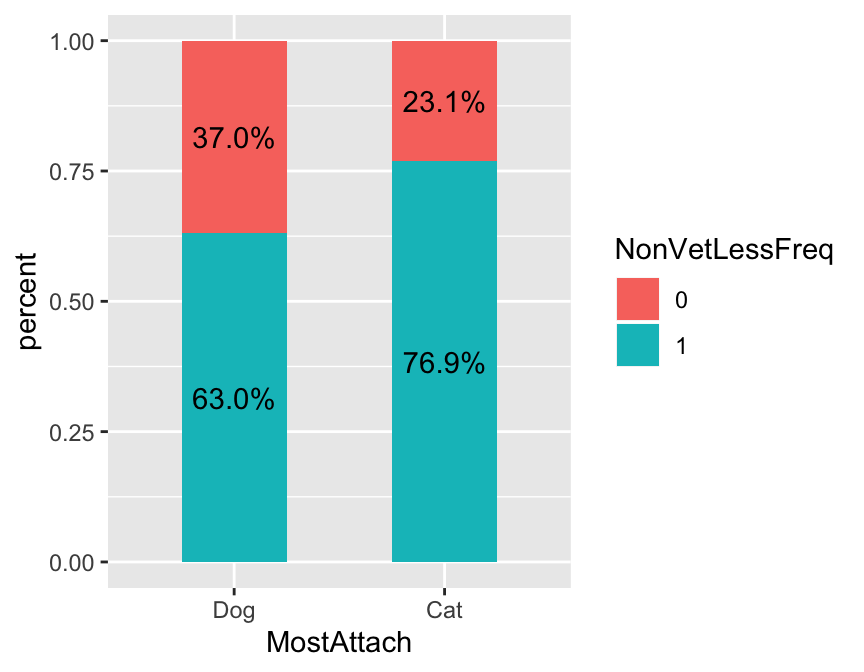

```
##                Estimate Std. Error   z value   Pr(>|z|)
## (Intercept)   0.5328045  0.2424380 2.1976944 0.02797089
## MostAttachCat 0.6711683  0.7015047 0.9567552 0.33869083
```

##### 2.2.3 (Yes:1;No:0): In the past 12 months, have you visited a veterinarian for preventative care for your pet?

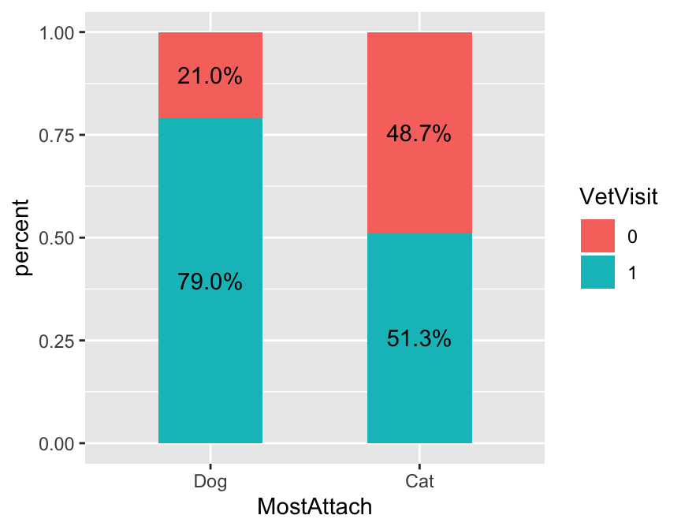

```
##                Estimate Std. Error  z value     Pr(>|z|)
## (Intercept)    1.326002  0.1640923  8.08083 6.432758e-16
## MostAttachCat -1.274709  0.2293124 -5.55883 2.715885e-08
```

##### 2.2.4 (Yes:1;No:0) : Thinking about the time since the COVID-19 outbreak began, have you used these preventative veterinary services less frequently than before the outbreak began?

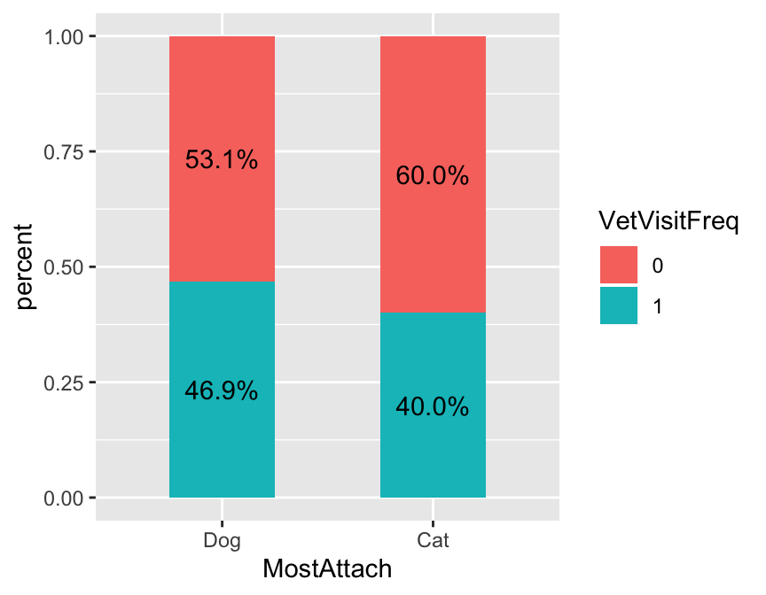

```
##                 Estimate Std. Error    z value  Pr(>|z|)
## (Intercept)   -0.1244542  0.1506204 -0.8262773 0.4086468
## MostAttachCat -0.2810109  0.2734407 -1.0276851 0.3040980
```

##### 2.2.5 (Yes:1;No:0): Thinking about the time since the COVID-19 outbreak began, has your pet had any health issues (e.g. been sick or injured) that required a veterinarian?

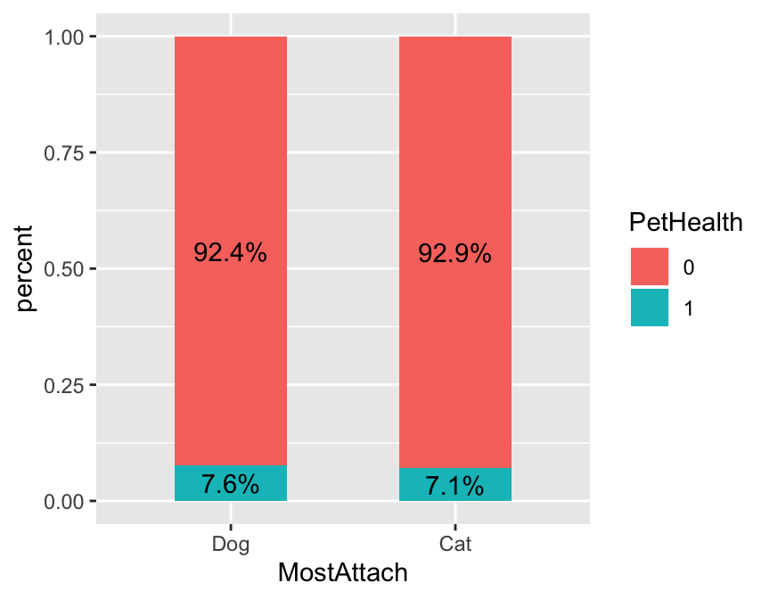

```
##                  Estimate Std. Error   z value     Pr(>|z|)
## (Intercept)   -2.49950545  0.2522982 -9.906951 3.883172e-23
## MostAttachCat -0.07933302  0.4018205 -0.197434 8.434879e-01
```